# Plotting & Programming with Python - Afternoon Day 1

## 28 Feb 2018 - Washington State University

# Setup

- Spyder
- **Jupyter Notebook**

## Make sure you have:

- iPython/Anaconda installed
- The data downloaded and unzipped in a "Data" folder
  - **Be sure you know the path to this folder!**

If you don't already have these downloaded, let someone know.

# Running and Quitting

## Starting Jupyter Notebook or Spyder

**Option 1:** Open anaconda launcher. You can open either Spyder or Jupyter Notebook from this window. *Note: If this is your first time launching Jupyter Notebook, pay attention to the terminal window that pops up. You will likely need to copy and paste something into your browser to pull up the Jupyter page.*

**Option 2:** Open a terminal window (mac) or your equivalent command line program.

- Jupyter notebook: `jupyter notebook`
- Spyder: `spyder`

### When you open Jupyter Notebook...

- This opens in your default web browser (I use chrome).
- The server for this runs locally on your machine. You won't need an internet connection to use Jupyter Notebook. The server does the work, the web browser just renders the notebook.

### When you open Spyder...

- You get an interactive environment similar to MATLAB.

I'll be working with Jupyter Notebook because it's easier to include large sections of text. I would recommend using Jupyter notebook for anything you plan to share with collaborators or others. Usually, if I'm doing something semi-final that I may show someone else, I'll document my work in Jupyter notebook. However, if I don't have a solid plan or I'm just quickly making figures for something, I'll use Spyder. No one sees those.

### This is a cell!

Pressing "esc" will turn the box around this blue, and pressing enter will turn it green. When typing in a cell, the return key enters down a line.

- Blue = command mode
  - Editing "notebook level" features
- Green = edit mode
  - Editing code and notebook content

### To run a cell:

Hold down shift and hit enter!

In Spyder you can hit the "run" button at the top of the page or you can highlight the code you'd like to run and hold down shift and hit enter

## Some shortcuts:

In command mode, pressing the 'h' key will bring up a list of shortcuts

- "B" - Creates new cell below current cell
- "A" - Creates new cell above
- "x" - Deletes current cell
- "Z" - Undoes last actions
- Shift + enter runs whatever is in the cell

### Exercise:

- Switch between command and edit mode
- Create a new cell with keyboard shortcuts in command mode
- Delete that cell with keyboard shortcuts in command mode

## Annotation - Markdown cells

There are multiple cell types. Code, markdown, raw NB convert, and heading.

- Code: This is where you'll write and run your code. If you write code in any other format, it won't run like code.
- Markdown: This is where you annotate. This is a markdown cell.

#### You can use "#" to denote a heading, the more # you add, the smaller the heading (this is a ### heading)

- You can make lists:
  - Bullets can be made with * or -
  - To make a sub-list, just hit tab before the bullet
- You can also make numbered lists
  1. Numbered lists can be made with numbers
  2. You don't need to use the correct number, jupyter will number correctly fot you!

Line breaks don't matter

But a blank line denotes a new paragraph

You can [create links](http://software-carpentry.org) using `[...](...)` (or you can use HTML)

- *You can use HTML*
- You can write in plain text
- And you can write equations using [latex](https://www.codecogs.com/latex/eqneditor.php) - just put two dollar signs around your equation! $$ \lambda = \frac{1}{\sqrt{2} ed^{2} \frac{N}{V}} $$
- You can insert images using HTML or with code

### Exercise:

- Create a cell and change the type to markdown.
- Create a list using both numbers and bullets.

# Variables and Assignment

We can assign a value to a variable by using `=`. We can print the value of this variable back out by using the `print()` command.

**Assigning variables**

- Variables are case sensitive!
- Variables must be assigned before they can be used.
- They can contain only letters, digits, and underscores (`_`).
- They can not start with a digit.
- Variables that are named start with an underscore have a special meaning. We won't get into this right now.
- *Be sure to use meaningful variable names! You (and anyone else who reads your code) will be thankful later*

**Using the print command**

- The `print()` command prints things as text.
- We 'call the function' by using it's name (in this case, `print`).
- We provide a value (or whatever we are printing) to the function by places it in the parenthesis after the function.
  - These values are called arguments
- If we want to add a string, we denote it by using 'single quotes.'
- Python will add a space between arguments
- At the end of the print command, python will wrap to a new line.

```python
weight_kg = 55
```

```python
print(weight_kg)
print('Weight in kg:', weight_kg)
```

```
55
Weight in kg: 55
```

```python
weight_lb = weight_kg * 2.2
```

We can also do math and include strings in the print command.

Note: strings are denoted by ''

```python
print('Weight in pounds:', 2.2 * weight_kg)
```

```
Weight in pounds: 121.00000000000001
```

If we want to change the value of the variable, we can just re-assign a number to that variable. This will overwrite the fist variable.

```python
weight_kg = 100
```

We can do math with variables, too.

```python
print('weight in kilograms is now:', weight_kg, 'weight in pounds is still', weight_lb)
```

```
weight in kilograms is now: 100 weight in pounds is still 121.00000000000001
```

Now, if we overwrite the weight_kg variable, we change the value that is stored in that variable. However, this does not have any influence on the value stored in weight_lb

### Exercise:

Scenario:

X = 58  
Y = X  
X = 2  
What is the final value of X? What is the final value of Y?  
Predict this without running the code, then test it to varify your prediction.

```python
X = 58
Y = X
X = 2

print(X)
print(Y)
```

```
2
58
```

# Data Types and Type Conversion

Everything in python has a type.

- Integer (int): any whole positive or negative number (43 or -23).
- Floating point number (float): any real number (-4.293 or 2.5).
- String (str): a string of characters (a word).
  - Written in single or double quoate (as long as they match).
    - These quotations aren't printed.

```python
print(type(52))
```

```
<class 'int'>
```

```python
fitness = 'average'
print(type(fitness))
```

```
<class 'str'>
```

A value's type determines what can be done with it.

```python
print( 4 - 3)
```

```
1
```

```python
print('hello' - h)
```

```
---------------------------------------------------------------------------
NameError                                 Traceback (most recent call last)
<ipython-input-27-f8f2a4613870> in <module>()
----> 1 print('hello' - h)

NameError: name 'h' is not defined
```

However, this doesn't mean that there are no operaters that can't be used on strings.

- '+' can add two strings together
- '*' can multiply one string a number of times.

```python
print('fitness ' + fitness)

print('String 1' + 'String 2')
```

```
fitness average
String 1String 2
```

```python
print('Operator' * 5)
```

```
OperatorOperatorOperatorOperatorOperator
```

Strings have lengths but numbers do not

```python
print(len('fitness'))
```

```
7
```

```python
print(len(fitness))
```

```
7
```

```python
print(len(563957))
```

```
---------------------------------------------------------------------------
TypeError                                 Traceback (most recent call last)
<ipython-input-35-c76e753e75cc> in <module>()
----> 1 print(len(563957))

TypeError: object of type 'int' has no len()
```

We can not mix numbers and strings in one object.

```python
print('50' + weight_kg)
```

```
---------------------------------------------------------------------------
TypeError                                 Traceback (most recent call last)
<ipython-input-38-502ff2b58fd1> in <module>()
----> 1 print('50' + weight_kg)

TypeError: must be str, not int
```

We must change the type of the number to string in order to do this. Would the string '50' plus the weight_kg variable be 150 or 50100?

We can convert numbers back and fourth from strings to integers

```python
print(2 + int('1'))
print(str(1) + '2')
```

```
3
12
```

We can mix integrers and floats freely in operations such as:

```python
weight_unit = 'kilograms'
print('weight in', weight_unit, 'is', weight_kg)
```

```
weight in kilograms is 100
```

```python
print('half the weight in', weight_unit, 'is', weight_kg / 2)
```

```
half the weight in kilograms is 50.0
```

Once we have a string, we can subset it, meaning we can pick out different parts of the string. This is particularly helpful when your string also happens to be your filename. For now, we will continue to work with our 'kilograms' string.

Strings are treated as a list of charactors in a specific order, so we can assign each letter in the string a location. We can subset using square brackets.

```python
print(weight_unit[4])
```

```
g
```

If we want to select more than one letter, we can use : to represent "through". Remember that **python counts from 0**.

```python
print(weight_unit[1:4])
```

```
ilo
```

It's important to remember how python counts whenever doing any sort of subsetting. Even though the length of each of the data elements is three in the image below, the letters are in columns 0 through 2.

[figure not shown]

## Who's who

You can use the `%who` command to see what modules/variables you have loaded. This command only works with iPython, so if you're every working with regular python, it won't work. However, it will work with both spyder and jupyter notebook.

```python
%whos
```

```
Variable      Type     Data/Info
--------------------------------
X             int      2
Y             int      58
fitness       str      average
weight_kg     int      100
weight_lb     float    121.00000000000001
weight_unit   str      kilograms
x             int      56
```

We can subset this because python treates it as a list of letters and not as one single thing. However, python treates numbers as one individual value, meaning we can not subset it.

### Exercise:

- Create an object 'a' with a value of 242. What happens when you try to use brackets to extract the '4'?
- Use brackets to extract 'gram' from our weight_unit variable (kilogram).
- Create an object 'b' with a value of d1c2. What happens?

```python
a = 242
print(a[1])
```

```
---------------------------------------------------------------------------
TypeError                                 Traceback (most recent call last)
<ipython-input-49-eb18f89b106a> in <module>()
      1 a = 242
----> 2 print(a[1])

TypeError: 'int' object is not subscriptable
```

```python
print(weight_unit[4:8])
```

```
gram
```

```python
b = d1c2
```

```
---------------------------------------------------------------------------
NameError                                 Traceback (most recent call last)
<ipython-input-51-392d7d134123> in <module>()
----> 1 b = d1c2

NameError: name 'd1c2' is not defined
```

### Slicing Exercise:

Create an object called atom_name with the value 'carbon'. Print out carbon using the following subscripts.

1. **[value:value]**
2. **[value:]** What does not having a value after the colon do?
3. **[:value]** What does not having a value before the colon do?
4. **[:]** What does only having a colon do?
5. **[value:negative value]** What does having a negative number in one of the places do?

```python
atom_name = 'carbon'
print(atom_name[2:5])
print(atom_name[4:])
print(atom_name[:4])
print(atom_name[:])
print(atom_name[3:-3])
```

```
rbo
on
carb
carbon
```

# Built in Functions and Help

```python
# This is a comment
x = 4 # comment
print(x) # another comment
```

```
4
```

## Commonly-used built in functions include `min`, `max`, and `round`.

## `min()` and `max()`

These work on both numbers and character strings. For character strings, they compare: 0-9, A-Z, a-z

```python
print(min(1,2,3))
print(min('A','B','C'))
print(min('String!'))
```

```
1
A
!
```

However, **functions may only work for certain combinations of arguments**. You can not compare an integer with a string. Also, you must include at least one argument.

```python
print(max(4, 'A'))
```

```
---------------------------------------------------------------------------
TypeError                                 Traceback (most recent call last)
<ipython-input-60-9a376057b749> in <module>()
----> 1 print(max(4, 'A'))

TypeError: '>' not supported between instances of 'str' and 'int'
```

## `round()`

The round function is useful for rounding numbers. You can specify the number of decimal places you'd like to round to.

**Some functions have default values for some arguments**. In the round command, the default is zero decimal places. However, we can specify how many we'd like if we don't want the default.

### `round(number to round, number of decimal places)`

```python
print(round(3.572042048573920))
```

```
4
```

```python
print(round(3.24274927543, 3))
```

```
3.243
```

## Built-in help function in ipython

Every built in function has online documentation. If you're unsure what the default is for a function or what arguments it can be given (and how to give them) te documentation is a great resource! There are two ways to access this documentation from either inside Jupyter Notebook or within Spyder. You can also google it. Google has all the documentation and examples anyone could ever need!

To get help without google, you can:

- Add ? after a function
- Type `help(function)`

Bonus way to Jupyter notebook:

- Type the function then hold shift and press tab

```python
round?
```

```python
help(round)
```

```
Help on built-in function round in module builtins:

round(...)
    round(number[, ndigits]) -> number

    Round a number to a given precision in decimal digits (default 0 digits).
    This returns an int when called with one argument, otherwise the
    same type as the number. ndigits may be negative.
```

```python
round()
```

[output not shown]

## Python Errors

When something is typed wrong we get an error. There are two types of common errors:

- Runtime error - This occurs when something is wrong while the program is executing
- Syntax error - This happens if something is mis-typed

```python
age = 53
remaining = 100 - agee #misspell age
```

```
---------------------------------------------------------------------------
NameError                                 Traceback (most recent call last)
<ipython-input-69-c8639d4ac203> in <module>()
      1 age = 53
----> 2 remaining = 100 - agee #misspell age

NameError: name 'agee' is not defined
```

```python
name = 'sarah
```

```
  File "<ipython-input-70-59c6e71b3b7e>", line 1
    name = 'sarah
                 ^
SyntaxError: EOL while scanning string literal
```

```python
age = = 5
```

```
  File "<ipython-input-71-d2068a7618fd>", line 1
    age = = 5
          ^
SyntaxError: invalid syntax
```

```python
print("Hello world"
```

```
  File "<ipython-input-72-f1e8f81143fa>", line 1
    print("Hello world"
                       ^
SyntaxError: unexpected EOF while parsing
```

### Exercise:

- Why don’t max and min return None when they are given no arguments?
- If Python starts counting from zero, and len returns the number of characters in a string, what index expression will get the last character in the string name?
- What does the bool() function do? How many arguments does it take? Try with different inputs.

# Libraries

A library is a collection of files (call *modules*) that contain functions for use by other programs. They can also contain numerican constants and other things.

- The *Python Standard Libaray* is an extersive suite of modules that come with Python.
- Many additional libraries are available

Libraries are collections of modules.

The first module we will import is the math module. To import a module, we use the `import` command.

- Python uses . to mean "part of"

```python
import math

print('pi is', math.pi)
print('cos(pi) is', math.cos(math.pi))
print(pi)
```

```
pi is 3.141592653589793
cos(pi) is -1.0
```

```
---------------------------------------------------------------------------
NameError                                 Traceback (most recent call last)
<ipython-input-76-c4c7fac61ff7> in <module>()
      3 print('pi is', math.pi)
      4 print('cos(pi) is', math.cos(math.pi))
----> 5 print(pi)

NameError: name 'pi' is not defined
```

### You can use `help` to learn more about a module in the same way we did for the function.

```python
help(math)
```

[output not shown]

[output cut: 220 more lines]

[output not shown]

Sometimes, we don't need a whole libary module, but just specific items. When we do this, we no longer need the prefix.

### We can specify these by using `from libaray import items`

```python
from math import cos, pi
print('cos(pi) is', cos(pi))
```

```
cos(pi) is -1.0
```

We can also create an alias for a module to shorten it during programs. Often for a module, there is a universally used alias. It's important to pay attention to this when turning to google for help, as many people online will use an alias, and you will need to make sure your code reflects your alias and not theirs.

Some common alias:

- matplotlib.pyplot as plt
- matplotlib as mpl
- numpy as np
- pandas as pd ### We specify an alias `import libaray as alias`

```python
import math as m
print('cos(pi) pi', m.cos(m.pi))
```

```
cos(pi) pi -1.0
```

# Reading Tabular Data Into Dataframes

There are a number of different modules that can help you read data into dataframes. Two of the most popular are NumPy and Pandas. Pandas is nice for statistics and tables with a date. These borrow many features from R's dataframes.

We can use Pandas to load in the CSV we have of the data. It is good practice to put the entire path to the dataset in regardless of the location of the script. We can check our current location by typing 'cd'. Note that this is the location you are currently running your script. Not the location of the script and not nessesarily the location of your data. If you use the entire path to your dataset, this location doesn't matter.

**If your file is not found** check where your data is stored and check your path! Note that I'm working on a Mac, if you're working on a PC your slashes may be the other direction.

```python
cd
```

```
/Users/Sarah
```

```python
import pandas as pd

data = pd.read_csv('/Users/Sarah/Downloads/data/gapminder_gdp_oceania.csv') # Mac
data = pd.read_csv(r'/Users/Sarah/Downloads/data/gapminder_gdp_oceania.csv') # Try this on a pc
data = pd.read_csv('\Users\Sarah\Downloads\data\gapminder_gdp_oceania.csv') # Try this too

print(data)
```

[output not shown]

In this dataset, the columns are observed variables and the rows are observations.

Pandas uses the backslash `\` to denote when a line has been wrapped because the output is too wide to fit the screen.

## Using `index_col` to specify that a column's value should be used a row headings

### `data = pd.read_csv('path', index_col='index column heading')`

```python
data = pd.read_csv('/Users/Sarah/Downloads/data/gapminder_gdp_oceania.csv', index_col='country')
print(data)
```

```
             gdpPercap_1952  gdpPercap_1957  gdpPercap_1962  gdpPercap_1967  \
country
Australia       10039.59564     10949.64959     12217.22686     14526.12465
New Zealand     10556.57566     12247.39532     13175.67800     14463.91893

             gdpPercap_1972  gdpPercap_1977  gdpPercap_1982  gdpPercap_1987  \
country
Australia       16788.62948     18334.19751     19477.00928     21888.88903
New Zealand     16046.03728     16233.71770     17632.41040     19007.19129

             gdpPercap_1992  gdpPercap_1997  gdpPercap_2002  gdpPercap_2007
country
Australia       23424.76683     26997.93657     30687.75473     34435.36744
New Zealand     18363.32494     21050.41377     23189.80135     25185.00911
```

## If we want more information about the dataframe, we can use the `DataFrame.info` command.

This shows us that:

- This is a DataFrame
- The two rows are named 'Australia' and 'New Zealand'
- We have 12 columns, each of which has an actual 64-bit floating point value. None of these values are null.
- This uses 208 bytes of memory

```python
data.info()
```

```
<class 'pandas.core.frame.DataFrame'>
Index: 2 entries, Australia to New Zealand
Data columns (total 12 columns):
gdpPercap_1952    2 non-null float64
gdpPercap_1957    2 non-null float64
gdpPercap_1962    2 non-null float64
gdpPercap_1967    2 non-null float64
gdpPercap_1972    2 non-null float64
gdpPercap_1977    2 non-null float64
gdpPercap_1982    2 non-null float64
gdpPercap_1987    2 non-null float64
gdpPercap_1992    2 non-null float64
gdpPercap_1997    2 non-null float64
gdpPercap_2002    2 non-null float64
gdpPercap_2007    2 non-null float64
dtypes: float64(12)
memory usage: 208.0+ bytes
```

## The `DataFrame.columns` variable stores information about the dataframe's columns.

Note that this is not a method like math.pi, this is data. Do not use () to try to call it.

*This is called a member variable or just a member*

```python
print(data.columns)
```

```
Index(['gdpPercap_1952', 'gdpPercap_1957', 'gdpPercap_1962', 'gdpPercap_1967',
       'gdpPercap_1972', 'gdpPercap_1977', 'gdpPercap_1982', 'gdpPercap_1987',
       'gdpPercap_1992', 'gdpPercap_1997', 'gdpPercap_2002', 'gdpPercap_2007'],
      dtype='object')
```

## Use `DataFrame.T` to transpose a dataframe.

Sometimes we want to treate columns as rows and vice versa. To transpose, we write `.T` after the dataframe. This doesn't change the data, just copies the view of it.

Like columns, this is a member variable.

```python
print(data.T)
```

```
country           Australia  New Zealand
gdpPercap_1952  10039.59564  10556.57566
gdpPercap_1957  10949.64959  12247.39532
gdpPercap_1962  12217.22686  13175.67800
gdpPercap_1967  14526.12465  14463.91893
gdpPercap_1972  16788.62948  16046.03728
gdpPercap_1977  18334.19751  16233.71770
gdpPercap_1982  19477.00928  17632.41040
gdpPercap_1987  21888.88903  19007.19129
gdpPercap_1992  23424.76683  18363.32494
gdpPercap_1997  26997.93657  21050.41377
gdpPercap_2002  30687.75473  23189.80135
gdpPercap_2007  34435.36744  25185.00911
```

## Use `DataFrame.describe` to get summary statistics about data.

`DataFrame.describe()` gets the summary statistics of only the columns that have numerical data. All other columns are ignored, unless you use the argument `include='all'`.

```python
print(data.describe())
```

```
       gdpPercap_1952  gdpPercap_1957  gdpPercap_1962  gdpPercap_1967  \
count        2.000000        2.000000        2.000000        2.000000
mean     10298.085650    11598.522455    12696.452430    14495.021790
std        365.560078      917.644806      677.727301       43.986086
min      10039.595640    10949.649590    12217.226860    14463.918930
25%      10168.840645    11274.086022    12456.839645    14479.470360
50%      10298.085650    11598.522455    12696.452430    14495.021790
75%      10427.330655    11922.958888    12936.065215    14510.573220
max      10556.575660    12247.395320    13175.678000    14526.124650

       gdpPercap_1972  gdpPercap_1977  gdpPercap_1982  gdpPercap_1987  \
count         2.00000        2.000000        2.000000        2.000000
mean      16417.33338    17283.957605    18554.709840    20448.040160
std         525.09198     1485.263517     1304.328377     2037.668013
min       16046.03728    16233.717700    17632.410400    19007.191290
25%       16231.68533    16758.837652    18093.560120    19727.615725
50%       16417.33338    17283.957605    18554.709840    20448.040160
75%       16602.98143    17809.077557    19015.859560    21168.464595
max       16788.62948    18334.197510    19477.009280    21888.889030

       gdpPercap_1992  gdpPercap_1997  gdpPercap_2002  gdpPercap_2007
count        2.000000        2.000000        2.000000        2.000000
mean     20894.045885    24024.175170    26938.778040    29810.188275
std       3578.979883     4205.533703     5301.853680     6540.991104
min      18363.324940    21050.413770    23189.801350    25185.009110
25%      19628.685413    22537.294470    25064.289695    27497.598692
50%      20894.045885    24024.175170    26938.778040    29810.188275
75%      22159.406358    25511.055870    28813.266385    32122.777857
max      23424.766830    26997.936570    30687.754730    34435.367440
```

### Exercise:

Read in europe.csv instead of oceania.csv and re-run all the cells

# Pandas DataFrames

A DataFrame is a collection of Series. The DataFrame is the way Pandas represents a table, and a Series is the data-structure Pandas uses to represent a column. Pandas is built on top of the NumPy library, which means that most of the methods that are defined for NumPy arrays also apply to Pandas Series/DataFrames.

## Selecting varlues

To access a value at position [i,j] of a DataFrame, we have two options, depending on the meaning of i in use. Remember that a DataFrame provides an index as a way to identify the rows of the table. A row, then, has a position inside the table as well as a lable, which uniquiely identifies its entry in the DataFrame.

## Use `DataFrame.iloc[...,...]` to select values by their (entry) position.

You can speify location by numerical index analogousy to 2D versions of character selection in strings.

```python
data = pd.read_csv('/Users/Sarah/Downloads/data/gapminder_gdp_europe.csv', index_col='country')
print(data)
```

```
                        gdpPercap_1952  gdpPercap_1957  gdpPercap_1962  \
country
Albania                    1601.056136     1942.284244     2312.888958
Austria                    6137.076492     8842.598030    10750.721110
Belgium                    8343.105127     9714.960623    10991.206760
Bosnia and Herzegovina      973.533195     1353.989176     1709.683679
Bulgaria                   2444.286648     3008.670727     4254.337839
Croatia                    3119.236520     4338.231617     5477.890018
Czech Republic             6876.140250     8256.343918    10136.867130
Denmark                    9692.385245    11099.659350    13583.313510
Finland                    6424.519071     7545.415386     9371.842561
France                     7029.809327     8662.834898    10560.485530
Germany                    7144.114393    10187.826650    12902.462910
Greece                     3530.690067     4916.299889     6017.190733
Hungary                    5263.673816     6040.180011     7550.359877
Iceland                    7267.688428     9244.001412    10350.159060
Ireland                    5210.280328     5599.077872     6631.597314
Italy                      4931.404155     6248.656232     8243.582340
Montenegro                 2647.585601     3682.259903     4649.593785
Netherlands                8941.571858    11276.193440    12790.849560
Norway                    10095.421720    11653.973040    13450.401510
Poland                     4029.329699     4734.253019     5338.752143
Portugal                   3068.319867     3774.571743     4727.954889
Romania                    3144.613186     3943.370225     4734.997586
Serbia                     3581.459448     4981.090891     6289.629157
Slovak Republic            5074.659104     6093.262980     7481.107598
Slovenia                   4215.041741     5862.276629     7402.303395
Spain                      3834.034742     4564.802410     5693.843879
Sweden                     8527.844662     9911.878226    12329.441920
Switzerland               14734.232750    17909.489730    20431.092700
Turkey                     1969.100980     2218.754257     2322.869908
United Kingdom             9979.508487    11283.177950    12477.177070

                        gdpPercap_1967  gdpPercap_1972  gdpPercap_1977  \
country
Albania                    2760.196931     3313.422188     3533.003910
Austria                   12834.602400    16661.625600    19749.422300
Belgium                   13149.041190    16672.143560    19117.974480
Bosnia and Herzegovina     2172.352423     2860.169750     3528.481305
Bulgaria                   5577.002800     6597.494398     7612.240438
```

[output cut: 76 more lines]

```
Italy                     24675.024460    27968.098170    28569.719700
Montenegro                 6465.613349     6557.194282     9253.896111
Netherlands               30246.130630    33724.757780    36797.933320
Norway                    41283.164330    44683.975250    49357.190170
Poland                    10159.583680    12002.239080    15389.924680
Portugal                  17641.031560    19970.907870    20509.647770
Romania                    7346.547557     7885.360081    10808.475610
Serbia                     7914.320304     7236.075251     9786.534714
Slovak Republic           12126.230650    13638.778370    18678.314350
Slovenia                  17161.107350    20660.019360    25768.257590
Spain                     20445.298960    24835.471660    28821.063700
Sweden                    25266.594990    29341.630930    33859.748350
Switzerland               32135.323010    34480.957710    37506.419070
Turkey                     6601.429915     6508.085718     8458.276384
United Kingdom            26074.531360    29478.999190    33203.261280
```

```python
data = pd.read_csv('/Users/Sarah/Downloads/data/gapminder_gdp_europe.csv', index_col='country')
print(data.iloc[0,0])
```

```
1601.056136
```

## Use `DataFrame.loc[..., ...]` to select values by their (entry) label.

Can specify location by row name analogously to 2D version of dictionary keys.

```python
print(data.loc["Albania","gdpPercap_1952"])
```

```
1601.056136
```

## Use `:` on its own to mean all columns or all rows.

We don't even need to include this when specifying columns or rows by name.

For **columns**, we can say:

- `data.loc["Albania", :]`
- `data.loc["Albania"]` and will get the same result.

For **rows**, we can say:

- `data.loc[:, "gdpPercap_1952"]`
- `data.gdpPercap_1952`
- `data["gdpPercap_1952"]` and will get the same result.

```python
print(data.loc['Albania', :])
```

```
gdpPercap_1952    1601.056136
gdpPercap_1957    1942.284244
gdpPercap_1962    2312.888958
gdpPercap_1967    2760.196931
gdpPercap_1972    3313.422188
gdpPercap_1977    3533.003910
gdpPercap_1982    3630.880722
gdpPercap_1987    3738.932735
gdpPercap_1992    2497.437901
gdpPercap_1997    3193.054604
gdpPercap_2002    4604.211737
gdpPercap_2007    5937.029526
Name: Albania, dtype: float64
```

```python
print(data.loc['Albania'])
```

```
gdpPercap_1952    1601.056136
gdpPercap_1957    1942.284244
gdpPercap_1962    2312.888958
gdpPercap_1967    2760.196931
gdpPercap_1972    3313.422188
gdpPercap_1977    3533.003910
gdpPercap_1982    3630.880722
gdpPercap_1987    3738.932735
gdpPercap_1992    2497.437901
gdpPercap_1997    3193.054604
gdpPercap_2002    4604.211737
gdpPercap_2007    5937.029526
Name: Albania, dtype: float64
```

```python
print(data.loc[:, "gdpPercap_1952"])
```

```
country
Albania                    1601.056136
Austria                    6137.076492
Belgium                    8343.105127
Bosnia and Herzegovina      973.533195
Bulgaria                   2444.286648
Croatia                    3119.236520
Czech Republic             6876.140250
Denmark                    9692.385245
Finland                    6424.519071
France                     7029.809327
Germany                    7144.114393
Greece                     3530.690067
Hungary                    5263.673816
Iceland                    7267.688428
Ireland                    5210.280328
Italy                      4931.404155
Montenegro                 2647.585601
Netherlands                8941.571858
Norway                    10095.421720
Poland                     4029.329699
Portugal                   3068.319867
Romania                    3144.613186
Serbia                     3581.459448
Slovak Republic            5074.659104
Slovenia                   4215.041741
Spain                      3834.034742
Sweden                     8527.844662
Switzerland               14734.232750
Turkey                     1969.100980
United Kingdom             9979.508487
Name: gdpPercap_1952, dtype: float64
```

```python
print(data.gdpPercap_1952)
```

```
country
Albania                    1601.056136
Austria                    6137.076492
Belgium                    8343.105127
Bosnia and Herzegovina      973.533195
Bulgaria                   2444.286648
Croatia                    3119.236520
Czech Republic             6876.140250
Denmark                    9692.385245
Finland                    6424.519071
France                     7029.809327
Germany                    7144.114393
Greece                     3530.690067
Hungary                    5263.673816
Iceland                    7267.688428
Ireland                    5210.280328
Italy                      4931.404155
Montenegro                 2647.585601
Netherlands                8941.571858
Norway                    10095.421720
Poland                     4029.329699
Portugal                   3068.319867
Romania                    3144.613186
Serbia                     3581.459448
Slovak Republic            5074.659104
Slovenia                   4215.041741
Spain                      3834.034742
Sweden                     8527.844662
Switzerland               14734.232750
Turkey                     1969.100980
United Kingdom             9979.508487
Name: gdpPercap_1952, dtype: float64
```

```python
print(data["gdpPercap_1952"])
```

```
country
Albania                    1601.056136
Austria                    6137.076492
Belgium                    8343.105127
Bosnia and Herzegovina      973.533195
Bulgaria                   2444.286648
Croatia                    3119.236520
Czech Republic             6876.140250
Denmark                    9692.385245
Finland                    6424.519071
France                     7029.809327
Germany                    7144.114393
Greece                     3530.690067
Hungary                    5263.673816
Iceland                    7267.688428
Ireland                    5210.280328
Italy                      4931.404155
Montenegro                 2647.585601
Netherlands                8941.571858
Norway                    10095.421720
Poland                     4029.329699
Portugal                   3068.319867
Romania                    3144.613186
Serbia                     3581.459448
Slovak Republic            5074.659104
Slovenia                   4215.041741
Spain                      3834.034742
Sweden                     8527.844662
Switzerland               14734.232750
Turkey                     1969.100980
United Kingdom             9979.508487
Name: gdpPercap_1952, dtype: float64
```

## Select multiple columns or rows using `DataFrame.loc` and a named slice.

In this code, we discover that **slicing using ```loc``` is inclusive at both ends**, which differs from **slicing using ```iloc```, where slicing indicates everything up to but not including** the final index.

```python
print(data.loc['Italy':'Poland', 'gdpPercap_1962':'gdpPercap_1972'])
```

```
             gdpPercap_1962  gdpPercap_1967  gdpPercap_1972
country
Italy           8243.582340    10022.401310    12269.273780
Montenegro      4649.593785     5907.850937     7778.414017
Netherlands    12790.849560    15363.251360    18794.745670
Norway         13450.401510    16361.876470    18965.055510
Poland          5338.752143     6557.152776     8006.506993
```

## Result of slicing can be used in further operations.

- Typically, we aren't just printing slices.
- All statistical metrics that work on dataframes also work on slices

```python
print(data.loc['Italy':'Poland', 'gdpPercap_1962':'gdpPercap_1972'].max())
```

```
gdpPercap_1962    13450.40151
gdpPercap_1967    16361.87647
gdpPercap_1972    18965.05551
dtype: float64
```

```python
print(data.loc['Italy':'Poland', 'gdpPercap_1962':'gdpPercap_1972'].min())
```

```
gdpPercap_1962    4649.593785
gdpPercap_1967    5907.850937
gdpPercap_1972    7778.414017
dtype: float64
```

## Use comparisons to select data based on value.

- Comparison is applied element by element
- Returns a similarly-shaped dataframe of `True` and `False`

```python
subset = data.loc['Italy':'Poland', 'gdpPercap_1962':'gdpPercap_1972']
# print('Subset of data', subset)

print('Where are value large?', subset > 10000)
```

```
Where are value large?              gdpPercap_1962  gdpPercap_1967  gdpPercap_1972
country
Italy                 False            True            True
Montenegro            False           False           False
Netherlands            True            True            True
Norway                 True            True            True
Poland                False           False           False
```

## Select values or NaN using a Boolean mask.

- A frame full of Booleans is sometimes called a mask because of how it can be used.
- Get the value where the mask is true, and NaN (Not a Number) where it is false.
- Useful because NaNs are ignored by operations like max, min, average, etc.

```python
mask = subset > 10000
print(subset[mask])
```

```
             gdpPercap_1962  gdpPercap_1967  gdpPercap_1972
country
Italy                   NaN     10022.40131     12269.27378
Montenegro              NaN             NaN             NaN
Netherlands     12790.84956     15363.25136     18794.74567
Norway          13450.40151     16361.87647     18965.05551
Poland                  NaN             NaN             NaN
```

```python
print(subset.describe())
```

```
       gdpPercap_1962  gdpPercap_1967  gdpPercap_1972
count        5.000000        5.000000        5.000000
mean      8894.635868    10842.506571    13162.799194
std       4093.410673     4855.106424     5517.298708
min       4649.593785     5907.850937     7778.414017
25%       5338.752143     6557.152776     8006.506993
50%       8243.582340    10022.401310    12269.273780
75%      12790.849560    15363.251360    18794.745670
max      13450.401510    16361.876470    18965.055510
```

```python
print(subset[mask].describe())
```

```
       gdpPercap_1962  gdpPercap_1967  gdpPercap_1972
count        2.000000        3.000000        3.000000
mean     13120.625535    13915.843047    16676.358320
std        466.373656     3408.589070     3817.597015
min      12790.849560    10022.401310    12269.273780
25%      12955.737547    12692.826335    15532.009725
50%      13120.625535    15363.251360    18794.745670
75%      13285.513523    15862.563915    18879.900590
max      13450.401510    16361.876470    18965.055510
```

## Split-Apply-Combine operations

Pandas vectorizing methods and grouping operations are features that provide users much flexibility to analyse their data.

For instance, let’s say we want to have a clearer view on how the european countries split themselves according to their GDP.

### `data.apply(lambda input: output)`

```python
mask_higher = data.apply(lambda x: x > x.mean())
mask_higher.head()
```

| country | gdpPercap_1952 | gdpPercap_1957 | gdpPercap_1962 | gdpPercap_1967 | gdpPercap_1972 | gdpPercap_1977 | gdpPercap_1982 | gdpPercap_1987 | gdpPercap_1992 | gdpPercap_1997 | gdpPercap_2002 | gdpPercap_2007 |
| --- | --- | --- | --- | --- | --- | --- | --- | --- | --- | --- | --- | --- |
| Albania | False | False | False | False | False | False | False | False | False | False | False | False |
| Austria | True | True | True | True | True | True | True | True | True | True | True | True |
| Belgium | True | True | True | True | True | True | True | True | True | True | True | True |
| Bosnia and Herzegovina | False | False | False | False | False | False | False | False | False | False | False | False |
| Bulgaria | False | False | False | False | False | False | False | False | False | False | False | False |

```python
wealth_score = mask_higher.aggregate('sum', axis=1)/len(data.columns)
print(wealth_score)
```

```
country
Albania                   0.000000
Austria                   1.000000
Belgium                   1.000000
Bosnia and Herzegovina    0.000000
Bulgaria                  0.000000
Croatia                   0.000000
Czech Republic            0.500000
Denmark                   1.000000
Finland                   1.000000
France                    1.000000
Germany                   1.000000
Greece                    0.333333
Hungary                   0.000000
Iceland                   1.000000
Ireland                   0.333333
Italy                     0.500000
Montenegro                0.000000
Netherlands               1.000000
Norway                    1.000000
Poland                    0.000000
Portugal                  0.000000
Romania                   0.000000
Serbia                    0.000000
Slovak Republic           0.000000
Slovenia                  0.333333
Spain                     0.333333
Sweden                    1.000000
Switzerland               1.000000
Turkey                    0.000000
United Kingdom            1.000000
dtype: float64
```

Finally, for each group in the `wealth_score` table, we sum their (financial) contribution across the years surveyed:

```python
data.groupby(wealth_score).sum()
```

|  | gdpPercap_1952 | gdpPercap_1957 | gdpPercap_1962 | gdpPercap_1967 | gdpPercap_1972 | gdpPercap_1977 | gdpPercap_1982 | gdpPercap_1987 | gdpPercap_1992 | gdpPercap_1997 | gdpPercap_2002 | gdpPercap_2007 |
| --- | --- | --- | --- | --- | --- | --- | --- | --- | --- | --- | --- | --- |
| 0.000000 | 36916.854200 | 46110.918793 | 56850.065437 | 71324.848786 | 88569.346898 | 104459.358438 | 113553.768507 | 119649.599409 | 92380.047256 | 103772.937598 | 118590.929863 | 149577.357928 |
| 0.333333 | 16790.046878 | 20942.456800 | 25744.935321 | 33567.667670 | 45277.839976 | 53860.456750 | 59679.634020 | 64436.912960 | 67918.093220 | 80876.051580 | 102086.795210 | 122803.729520 |
| 0.500000 | 11807.544405 | 14505.000150 | 18380.449470 | 21421.846200 | 25377.727380 | 29056.145370 | 31914.712050 | 35517.678220 | 36310.666080 | 40723.538700 | 45564.308390 | 51403.028210 |
| 1.000000 | 104317.277560 | 127332.008735 | 149989.154201 | 178000.350040 | 215162.343140 | 241143.412730 | 263388.781960 | 296825.131210 | 315238.235970 | 346930.926170 | 385109.939210 | 427850.333420 |

### Exercise:

- Practice workflow reading/using/writing data frames. With your neighbor:
  1. Read in the Asia data, assign to 'data2'
  2. Return summary stats for data2
  3. Transpose the data, assign to 'data2_t'
  4. What are the columns in data2_t?
  5. Check out the head() and tail() commands
  6. Return the first 10 rows of data2_t
  7. Pandas has a 'to_csv' function that writes dataframes to files. Write one of your dataframes to a file called 'processed.csv'.
  8. Remember file paths - do you know exactly where this csv ended up?
- Return columns France to Ireland, rows GPD from 1967 to 1997.
  - Assign to 'output'.
  - Filter 'output' to values larger than 17,000.
- Read in all the gapminder data with all countries (gapminder_all.csv). Group the dataframe by continent and find the maximum life expectancy for 2002.

# Plotting

## `matplotlib` is the most widely used scientific plotting library in Python.

Most commonly people use the sub-library called matplotlib.pyplot.

**For Jupyter notebook to render plots inline, we need to first use a magic command.**

```python
%matplotlib inline
import matplotlib.pyplot as plt
```

```
Text(0,0.5,'Position (km)')
```

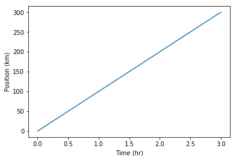

```python
time = [0, 1, 2, 3]
position = [0, 100, 200, 300]

plt.plot(time, position)
plt.xlabel('Time (hr)')
plt.ylabel('Position (km)')
```

## Plot data directly from a `Pandas dataframe`.

```python
print(data)
```

```
                        gdpPercap_1952  gdpPercap_1957  gdpPercap_1962  \
country
Albania                    1601.056136     1942.284244     2312.888958
Austria                    6137.076492     8842.598030    10750.721110
Belgium                    8343.105127     9714.960623    10991.206760
Bosnia and Herzegovina      973.533195     1353.989176     1709.683679
Bulgaria                   2444.286648     3008.670727     4254.337839
Croatia                    3119.236520     4338.231617     5477.890018
Czech Republic             6876.140250     8256.343918    10136.867130
Denmark                    9692.385245    11099.659350    13583.313510
Finland                    6424.519071     7545.415386     9371.842561
France                     7029.809327     8662.834898    10560.485530
Germany                    7144.114393    10187.826650    12902.462910
Greece                     3530.690067     4916.299889     6017.190733
Hungary                    5263.673816     6040.180011     7550.359877
Iceland                    7267.688428     9244.001412    10350.159060
Ireland                    5210.280328     5599.077872     6631.597314
Italy                      4931.404155     6248.656232     8243.582340
Montenegro                 2647.585601     3682.259903     4649.593785
Netherlands                8941.571858    11276.193440    12790.849560
Norway                    10095.421720    11653.973040    13450.401510
Poland                     4029.329699     4734.253019     5338.752143
Portugal                   3068.319867     3774.571743     4727.954889
Romania                    3144.613186     3943.370225     4734.997586
Serbia                     3581.459448     4981.090891     6289.629157
Slovak Republic            5074.659104     6093.262980     7481.107598
Slovenia                   4215.041741     5862.276629     7402.303395
Spain                      3834.034742     4564.802410     5693.843879
Sweden                     8527.844662     9911.878226    12329.441920
Switzerland               14734.232750    17909.489730    20431.092700
Turkey                     1969.100980     2218.754257     2322.869908
United Kingdom             9979.508487    11283.177950    12477.177070

                        gdpPercap_1967  gdpPercap_1972  gdpPercap_1977  \
country
Albania                    2760.196931     3313.422188     3533.003910
Austria                   12834.602400    16661.625600    19749.422300
Belgium                   13149.041190    16672.143560    19117.974480
Bosnia and Herzegovina     2172.352423     2860.169750     3528.481305
Bulgaria                   5577.002800     6597.494398     7612.240438
```

[output cut: 76 more lines]

```
Italy                     24675.024460    27968.098170    28569.719700
Montenegro                 6465.613349     6557.194282     9253.896111
Netherlands               30246.130630    33724.757780    36797.933320
Norway                    41283.164330    44683.975250    49357.190170
Poland                    10159.583680    12002.239080    15389.924680
Portugal                  17641.031560    19970.907870    20509.647770
Romania                    7346.547557     7885.360081    10808.475610
Serbia                     7914.320304     7236.075251     9786.534714
Slovak Republic           12126.230650    13638.778370    18678.314350
Slovenia                  17161.107350    20660.019360    25768.257590
Spain                     20445.298960    24835.471660    28821.063700
Sweden                    25266.594990    29341.630930    33859.748350
Switzerland               32135.323010    34480.957710    37506.419070
Turkey                     6601.429915     6508.085718     8458.276384
United Kingdom            26074.531360    29478.999190    33203.261280
```

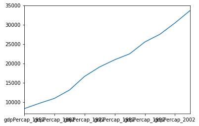

```python
data.loc['Belgium'].plot()
```

## Select and transform data, then plot it.

We can just type data.plot(), but it treats all the rows as the x axis. This isn't what we want. In order to have the columns treated as the x values, we need to transpose the data.

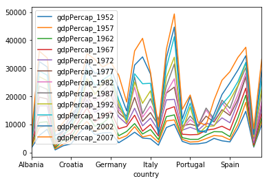

```python
data.plot()
```

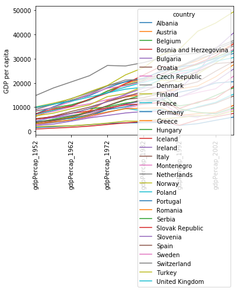

```python
data.T.plot()
plt.ylabel('GDP per capita')
plt.xticks(rotation = 90)
```

## Many styles of plots are available.

For example, do a bar plot using a fancier style.

```
Text(0,0.5,'GDP per capita')
```

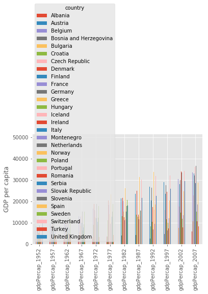

```python
plt.style.use('ggplot')
data.T.plot(kind = 'bar')
plt.xticks(rotation = 90)
plt.ylabel('GDP per capita')
```

If we want to change the labels on the x axis, we can do this. We will write a simple for loop to grab the dates out of each of the column titles. Don't worry if this doesn't make a lot of sense. Vikram will go over loops tomorrow afternoon.

For this example, we will create a new variable called years. We're going to make it as an empty list, then we will loop over all the columns and select only the last four letters of each column string (the date). We will then use the `.append` command to append the newly-parsed strings to the year list.

We can select how we want the line to look by specifying that after the x and y variables. g specifies that we want the line to be green, and -- indicates that it should be a dashed line. These are fun to play with and there are lot of guides online showing all the different options.

### `plt.plot(x,y, how to plot)`

```python
years = []
for col in data.columns:
    year = col[-4:]
    years.append(year)

print(years)
```

```
['1952', '1957', '1962', '1967', '1972', '1977', '1982', '1987', '1992', '1997', '2002', '2007']
```

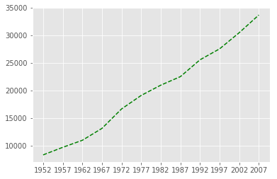

```python
gdp = data.loc['Belgium'].tolist()

plt.plot(years, gdp, 'g--')
```

## Can plot many sets of data together.

```
Text(0.5,0,'Year')
```

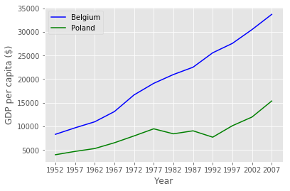

```python
gdp_Belgium = data.loc['Belgium']
gdp_Poland = data.loc['Poland']

plt.plot(years, gdp_Belgium, 'b-', label='Belgium')
plt.plot(years, gdp_Poland, 'g-', label='Poland')

plt.legend(loc='upper left')
plt.ylabel('GDP per capita ($)')
plt.xlabel('Year')
```

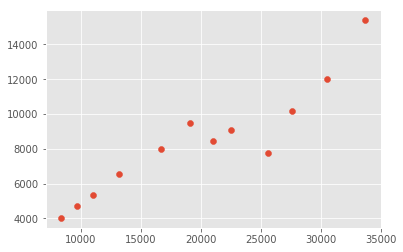

```python
plt.scatter(gdp_Belgium, gdp_Poland)
```

### Exercise:

- Read in the Europe data, with country as index column.
  - Make a plot with the minimum and maximum GPD over time.
  - Add a legend and rotate the x axis labels.
- Read in the gapminder csv with all countries.
  - Make a scatterplot showing GDP vs life expectancy in 2007.
  - Set the size of each point to reflect the population (hint: look at the documentation for plt.scatter)!